# 605-HW15-Calculus 3

Michael Y.

December 8, 2019

# HW15 - Calculus 3

## 1. Find the equation of the regression line for the given points.

#### Round any final values to the nearest hundredth, if necessary.

```r
# put the pairs into a list
points = list(
  c( 5.6,  8.8 ),
  c( 6.3, 12.4 ),
  c( 7,   14.8 ),
  c( 7.7, 18.2 ),
  c( 8.4, 20.8 )
  )
# Make the list into an array
points=simplify2array(points)
points
```

```
##      [,1] [,2] [,3] [,4] [,5]
## [1,]  5.6  6.3  7.0  7.7  8.4
## [2,]  8.8 12.4 14.8 18.2 20.8
```

```r
# get x
x=points[1,]
x
```

```
## [1] 5.6 6.3 7.0 7.7 8.4
```

```r
# get y
y=points[2,]
y
```

```
## [1]  8.8 12.4 14.8 18.2 20.8
```

```r
# regression
model1 =  lm(y~x)
model1
```

```
##
## Call:
## lm(formula = y ~ x)
##
## Coefficients:
## (Intercept)            x
##   -14.80000      4.25714
```

```r
summary(model1)
```

```
##
## Call:
## lm(formula = y ~ x)
##
## Residuals:
##     1     2     3     4     5
## -0.24  0.38 -0.20  0.22 -0.16
##
## Coefficients:
##               Estimate Std. Error  t value    Pr(>|t|)
## (Intercept) -14.800000   1.036533 -14.2784  0.00074442 ***
## x             4.257143   0.146617  29.0358 0.000089706 ***
## ---
## Signif. codes:  0 '***' 0.001 '**' 0.01 '*' 0.05 '.' 0.1 ' ' 1
##
## Residual standard error: 0.324551 on 3 degrees of freedom
## Multiple R-squared:  0.996454,   Adjusted R-squared:  0.995272
## F-statistic: 843.076 on 1 and 3 DF,  p-value: 0.0000897056
```

```r
beta=model1$coefficients
beta
```

```
##  (Intercept)            x
## -14.80000000   4.25714286
```

```r
intercept    =round(beta["(Intercept)"],2)
slope        =round(beta["x"],2)
eqn = paste("Regression line: y = ", intercept, "+", slope, "x")
eqn
```

```
## [1] "Regression line: y =  -14.8 + 4.26 x"
```

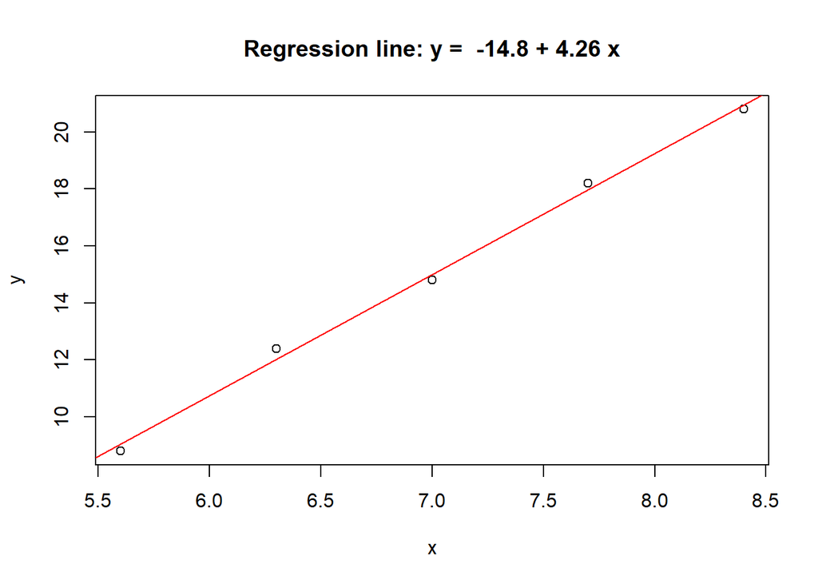

```r
plot(y~x, main=eqn)
abline(model1, col="red")
```

The formula for the regression line is $\boxed{y = -14.8 + 4.26 x}$ .

## 2. Find all local maxima, local minima, and saddle points for the function given below.

#### Write your answer(s) in the form ( x, y, z ).

#### Separate multiple points with a comma.

$f ( x, y ) = 24x - 6xy^2 - 8y^3$

To find the critical points, compute the first derivatives and set equal to zero:

$f_x = \frac{\partial}{\partial x}(24x - 6xy^2 -8y^3) = 24-6y^2 = 0 \implies4 = y^2 \implies y \in \{-2,2\}$ .

$f_y = \frac{\partial}{\partial y}(24x - 6xy^2 -8y^3) = -12xy-24y^2 = 0$ .

$xy =-2y^2 \implies (y=0) \vee (x=-2y)$ .

From above, we know that $y \in \{-2,2\}$ so we can disregard the case that $y=0$.

Therefore, $x \in \{4,-4\}$, i.e., $(x,y) \in \{(-4,2),(4,-2)\}$ .

Evaluating the function at these points, we obtain:

$f(-4,2) = 24\cdot(-4) - 6\cdot(-4)\cdot(2)^2 - 8\cdot(2)^3=-96+96-64=-64$  
$f(4,-2) = 24\cdot(4) - 6\cdot(4)\cdot(-2)^2 - 8\cdot(-2)^3=96-96+64=64$

Therefore, the *critical points* are $\boxed{(x,y,z) \in \{(-4,2,-64),(4,-2,64)\}}$ .

To determine whether these critical values are maxima, minima, or saddle points, we need to use the second partial derivative test:

$f_{xx} = \frac{\partial(f_{x})}{\partial x} = \frac{\partial}{\partial x}(24-6y^2) = 0$ .

$f_{yy} = \frac{\partial(f_{y})}{\partial y} = \frac{\partial}{\partial y}(-12xy-24y^2) = -12x-48y$ .

$f_{xy} = \frac{\partial(f_{x})}{\partial y} = \frac{\partial}{\partial y} (24-6y^2) = -12y$ $f_{yx} = \frac{\partial(f_{y})}{\partial x} = \frac{\partial}{\partial x} (-12xy-24y^2) = -12y = f_{xy}$ , as expected.

The discriminant $D(f(x,y)) = f_{xx}f_{yy} - f_{xy}f_{yx} = (0)(-12x-48y)-(-12y)^2=-144y^2$.  
At both critical points, $D(f(-4,2)) = D(f(4,-2)) = -144\cdot(\pm2)^2 = -576 < 0$ .

By the second partial derivative test, each of the two points $(x,y,z) \in \{(-4,2,-64),(4,-2,64)\}$ is a *saddle point* – there are no maxima nor minima.

## 3. A grocery store sells two brands of a product, the “house” brand and a “name” brand.

The manager estimates that if she sells the “house” brand for $x$ dollars and the “name” brand for $y$ dollars, she will be able to sell

- $81 - 21x + 17y$ units of the “house” brand and
- $40 + 11x - 23y$ units of the “name” brand.

### Step 1. Find the revenue function $R ( x, y )$ .

$$\begin{aligned}
R(x,y)
&= (81- 21x + 17y)x + (40 + 11x - 23y)y \\
&=81x - 21x^2 + 17xy + 40y +11xy- 23y^2 \\
&= -21x^2 -23y^2 + 28xy + 81x + 40y \\
\end{aligned}$$

### Step 2. What is the revenue if she sells the “house” brand for $2.30 and the “name” brand for $4.10?

##### Calculation functions:

```r
calcHouseUnits <- function(x,y)
{
  HouseUnits = 81 - 21*x + 17*y
  return(c(HouseUnits))
}

calcNameUnits <- function(x,y)
{
  NameUnits = 40 + 11*x + -23*y
  return(c(NameUnits))
}

calcRevenue <- function(x,y)
{
    r = - 21*x^2  - 23*y^2 + 28*x*y + 81*x + 40*y
    return(c(r))
}

calcRevenueWithRounding <- function(x,y)
{
  intHouseUnits = round(calcHouseUnits(x,y),0)
  intNameUnits = round(calcNameUnits(x,y),0)

  HouseRevenue = round(x,2) * intHouseUnits
  NameRevenue = round(y,2) * intNameUnits
  TotalRevenue = HouseRevenue + NameRevenue
return(c(TotalRevenue))
}
```

### Calculate revenue without requiring that the quantity of each item sold be an integer

```r
x=2.30
y=4.10

houseUnits=calcHouseUnits(x,y)
print(paste("Units of House brand sold: ", houseUnits,
            "at price of ",x," each ",
            "--> revenue = ", x*houseUnits))
```

```
## [1] "Units of House brand sold:  102.4 at price of  2.3  each  --> revenue =  235.52"
```

```r
nameUnits = calcNameUnits(x,y)
print(paste("Units of name brand sold: ", nameUnits,
            "at price of ",y," each ",
            "--> revenue = ", y*nameUnits))
```

```
## [1] "Units of name brand sold:  -29 at price of  4.1  each  --> revenue =  -118.9"
```

```r
print(paste("Total revenue: ", x*houseUnits + y*nameUnits))
```

```
## [1] "Total revenue:  116.62"
```

```r
checkRevenue = calcRevenue(x,y)
print(paste("Double-check : ", checkRevenue))
```

```
## [1] "Double-check :  116.62"
```

### Re-calculate revenue, adding a requirement that the quantity of each item sold be an integer

```r
x=2.30
y=4.10

houseUnits=round(calcHouseUnits(x,y),0)
print(paste("Units of House brand sold: ", houseUnits,
            "at price of ",x," each ",
            "--> revenue = ", x*houseUnits))
```

```
## [1] "Units of House brand sold:  102 at price of  2.3  each  --> revenue =  234.6"
```

```r
nameUnits = round(calcNameUnits(x,y),0)
print(paste("Units of name brand sold: ", nameUnits,
            "at price of ",y," each ",
            "--> revenue = ", y*nameUnits))
```

```
## [1] "Units of name brand sold:  -29 at price of  4.1  each  --> revenue =  -118.9"
```

```r
print(paste("Total revenue: ", x*houseUnits + y*nameUnits))
```

```
## [1] "Total revenue:  115.7"
```

```r
checkRevenue = calcRevenueWithRounding(x,y)
print(paste("Double-check : ", checkRevenue))
```

```
## [1] "Double-check :  115.7"
```

*There is a problem with these figures* – because it is expecting that we would sell

- 102 units of the “house” brand, but
- -29 units of the “name” brand.

The latter figure is *negative.* **This is not possible.**

So, let’s restrict the quantities to be non-negative:

### Functions with non-negative quantity restrictions

```r
calcNonNegHouseUnits <- function(x,y)
{
  HouseUnits = 81 - 21*x + 17*y
  return(max(0,HouseUnits))
}

calcNonNegNameUnits <- function(x,y)
{
  NameUnits = 40 + 11*x + -23*y
  return(max(0,NameUnits))
}

#calcRevenue <- function(x,y)
#{
#    r = - 21*x^2  - 23*y^2 + 28*x*y + 81*x + 40*y
#    return(c(r))
#}

calcNonNegRevenueWithRounding <- function(x,y)
{
  intNonNegHouseUnits = round(calcNonNegHouseUnits(x,y),0)
  intNonNegNameUnits = round(calcNonNegNameUnits(x,y),0)

  NonNegHouseRevenue = round(x,2) * intNonNegHouseUnits
  NonNegNameRevenue = round(y,2) * intNonNegNameUnits
  NonNegTotalRevenue = NonNegHouseRevenue + NonNegNameRevenue

return(c(NonNegTotalRevenue))
}
```

### Calculate results with non-negative restrictions:

```r
x=2.30
y=4.10

NonNegHouseUnits=round(calcNonNegHouseUnits(x,y),0)
print(paste("Units of House brand sold: ", NonNegHouseUnits,
            "at price of ",x," each ",
            "--> revenue = ", x*NonNegHouseUnits))
```

```
## [1] "Units of House brand sold:  102 at price of  2.3  each  --> revenue =  234.6"
```

```r
NonNegNameUnits = round(calcNonNegNameUnits(x,y),0)
print(paste("Units of name brand sold: ", NonNegNameUnits,
            "at price of ",y," each ",
            "--> revenue = ", y*NonNegNameUnits))
```

```
## [1] "Units of name brand sold:  0 at price of  4.1  each  --> revenue =  0"
```

```r
print(paste("Total revenue: ", x*NonNegHouseUnits + y*NonNegNameUnits))
```

```
## [1] "Total revenue:  234.6"
```

```r
checkNonNegRevenue = calcNonNegRevenueWithRounding(x,y)
print(paste("Double-check : ", checkNonNegRevenue))
```

```
## [1] "Double-check :  234.6"
```

*Still there is a problem here:*  
Allowing us to override an otherwise negative quantity-sold with zero, while still setting a high nominal price for such item, would allow us to sell an arbitrary (i.e., infinite) quantity of the other item simply by making the price of the non-salable item arbitrarily high.

Under such model, the result would be an arbitrarily large amount of sales from from the house brand with zero sales of (expensive) name brand.

*This indicates that this problem is not well-formulated.*

### Revenue maximization?

The question doesn’t ask about maximization of revenue (which one would have expected it to ask…)

So, let’s compute it anyhow…

- $R_x = -42x +28y +81 = 0$
- $R_y = 28x -46y +40 = 0$

So, we have a system of 2 simultaneous equations in 2 unknowns:

$$\begin{cases}
\begin{aligned}
-42x +28y +81 &=0 \\
28x -46y +40 &= 0
\end{aligned}
\end{cases}$$

Multiplying the second equation by $\frac{3}{2}$ gives us
$$\begin{cases}
\begin{aligned}
-42x +28y +81 &=0 \\
42x -69y +60 &= 0
\end{aligned}
\end{cases}$$

Adding together gives us

$-41y+141=0$ , so $y = \frac{141}{41}\approx 3.43902439$ .

From the above equations, $x = \frac{28y+81}{42}=\frac{28 \cdot\frac{141}{41}+81}{42} =\frac{7269}{1722}\approx 4.22125436$ .

So, the critical point (which we assume will be a maximum) is (housePrice,namePrice)=$(x^*,y^*)=\left(\frac{7269}{1722},\frac{141}{41}\right)\approx(4.22125436,3.43902439)$

### Solve system of 2 equations using `rref` from `pracma`

```r
Rx = c(-42,28,-81)
Ry = c(28,-46,-40)
eqns <- rbind(Rx,Ry)
eqns
```

```
##    [,1] [,2] [,3]
## Rx  -42   28  -81
## Ry   28  -46  -40
```

```r
result <- rref(eqns)
result
```

```
##    [,1] [,2]       [,3]
## Rx    1    0 4.22125436
## Ry    0    1 3.43902439
```

```r
soln <- result[,3]
soln
```

```
##         Rx         Ry
## 4.22125436 3.43902439
```

### Perform calculations on $(x^{*},y^{*}) =(4.221254355 , 3.43902439)$

```r
xstar=soln["Rx"]
ystar=soln["Ry"]



starhouseUnits=calcHouseUnits(xstar,ystar)
print(paste("Units of House brand sold: ", starhouseUnits,
            "at price of ",xstar," each ",
            "--> revenue = ", xstar*starhouseUnits))
```

```
## [1] "Units of House brand sold:  50.8170731707317 at price of  4.2212543554007  each  --> revenue =  214.511791450667"
```

```r
starnameUnits = calcNameUnits(xstar,ystar)
print(paste("Units of name brand sold: ", starnameUnits,
            "at price of ",ystar," each ",
            "--> revenue = ", ystar*starnameUnits))
```

```
## [1] "Units of name brand sold:  7.33623693379792 at price of  3.4390243902439  each  --> revenue =  25.2294977479392"
```

```r
print(paste("Total revenue: ", xstar*starhouseUnits + ystar*starnameUnits))
```

```
## [1] "Total revenue:  239.741289198606"
```

```r
starrevenue = calcRevenue(xstar,ystar)
starrevenue
```

```
##         Rx
## 239.741289
```

##### The above indicates that we generate revenue of $$239.741289199$.

Of course, we should assume that

- we can’t sell fractional units, and
- each unit price should be rounded to cents.

This introduces an “integer programming” problem, which can be considerably more difficult than a linear programming problem, because the result obtained from rounding the quantities to the closest integer may be inferior to rounding to the more distant integer.

Ignoring such issue, we obtain a slightly smaller result:

### Perform calculations on $(x^{*},y^{*}) =(4.22 , 3.44)$

```r
roundxstar=round(xstar,2)
roundystar=round(ystar,2)

intstarhouseUnits=round(calcHouseUnits(roundxstar,roundystar),0)
print(paste("Units of House brand sold: ", intstarhouseUnits,
            "at price of ",roundxstar," each ",
            "--> revenue = ", roundxstar*intstarhouseUnits))
```

```
## [1] "Units of House brand sold:  51 at price of  4.22  each  --> revenue =  215.22"
```

```r
intstarnameUnits = round(calcNameUnits(roundxstar,roundystar),0)
print(paste("Units of name brand sold: ", intstarnameUnits,
            "at price of ",roundystar," each ",
            "--> revenue = ", roundystar*intstarnameUnits))
```

```
## [1] "Units of name brand sold:  7 at price of  3.44  each  --> revenue =  24.08"
```

```r
print(paste("Total revenue: ", roundxstar*intstarhouseUnits + roundystar*intstarnameUnits))
```

```
## [1] "Total revenue:  239.3"
```

```r
starrevenue = calcRevenueWithRounding(roundxstar,roundystar)
starrevenue
```

```
##    Rx
## 239.3
```

##### The above indicates that we generate revenue of $$239.3$.

### Confirm maximum

To verify that this critical point is in fact a maximum, consider the second derivative test:

$R_x = -42x +28y +81 = 0$ $R_y = 28x -46y +40 = 0$

$R_{xx} = \frac{\partial(R_{x})}{\partial x} = \frac{\partial}{\partial x}(-42x +28y +81) = -42$ .

$R_{yy} = \frac{\partial(R_{y})}{\partial y} = \frac{\partial}{\partial y}(28x -46y +40) = -46$ .

$R_{xy} = \frac{\partial(R_{x})}{\partial y} = \frac{\partial}{\partial y} ( -42x +28y +81) = 28$ $R_{yx} = \frac{\partial(R_{y})}{\partial x} = \frac{\partial}{\partial x} (28x -46y +40) = 28 = f_{xy}$ , as expected.

The discriminant
$$\begin{aligned}
D(f(x,y))
= R_{xx}R_{yy} - R_{xy}R_{yx}
&= (-42)(-46)-(28)^2\\
&=1932-784\\
&=1148\\
&>0
\end{aligned}$$
.

Because

- $D(R(x,y))>0 \quad\forall (x,y)$ , and
- $R_{xx}(x,y)<0 \quad\forall(x,y)$,

the critical point (4.22,3.44) is a *maximum* .

### However, there is still one problem here:

Generally a “house” brand is *less expensive* than a “name” brand.

The result of this optimization is to select

- a *higher price* (4.22) for the *house brand* and
- a *lower price* (3.44) for the *name brand*.

*This does not make sense*, and further suggests that the model is not well-formulated.

## 4. A company has a plant in Los Angeles and a plant in Denver.

The firm is committed to produce a total of 96 units of a product each week.

The total weekly cost is given by $C(x, y) = \frac{1}{6}x^2 + \frac{1}{6}y^2 + 7x + 25y + 700$ , where

- $x$ is the number of units produced in Los Angeles and
- $y$ is the number of units produced in Denver.

How many units should be produced in each plant to **minimize** the total weekly cost?

First, note that $x+y=96$, so $y=96-x$ .

Next, compute the derivative $\frac{dC}{dx}$ and set equal to zero:

$C' = \frac{dC}{dx} = \frac{2(x-75)}{3}=\frac{2}{3}x-50=0 \\ \implies x=75 \\ \implies y=96-x=96-75=21$.

To confirm that this is a *minimum*, we look at the second derivative test:

$C'' = \frac{d^2C}{dx^2} = \frac{2}{3} > 0$.

Because the second derivative is positive, this confirms that the critical point is a minimum.

This means that:

- 75 units should be produced in Los Angeles
- 21 units should be produced in Denver

Under the above allocation, the total weekly cost is minimized at $C(75,21) = \$2,761$ .

## 5. Evaluate the double integral ${\iint\limits_R {e^{8x + 3y} dA}}$ on the given region .

R: $2 \le x \le 4$ and $2 \le y \le 4$

Write your answer in exact form without decimals.

$$\begin{aligned}
\int\limits_{2}^4 \left[\int\limits_{2}^4 {e^{8x + 3y} dx}\right] dy
&=\int\limits_{2}^4 \left[e^{3y}\int\limits_{2}^4 {e^{8x} dx}\right] dy \\
&=\int\limits_{2}^{4} e^{3y}\left[ \frac{e^{8x}}{8} \right]_{x=2}^{x=4} dy \\
&=\int\limits_{2}^{4} e^{3y}\left[ \frac{e^{32}-e^{16}}{8} \right] dy \\
&=\left[ \frac{e^{32}-e^{16}}{8} \right]\int\limits_{2}^{4} e^{3y} dy \\
&=\left[ \frac{e^{32}-e^{16}}{8} \right]\left[ \frac{e^{3y}}{3} \right]_{y=2}^{y=4} \\
&=\left[ \frac{e^{32}-e^{16}}{8} \right]\left[ \frac{e^{12}-e^{6}}{3} \right] \\
&=\left[ \frac{e^{32}e^{12}-e^{32}e^{6}-e^{16}e^{12}+e^{16}e^{6}}{24} \right] \\
&=\left[ \frac{e^{44}-e^{38}-e^{28}+e^{22}}{24} \right] \\ \\
&=\boxed{\frac{e^{22}}{24}\left[ {e^{22}-e^{16}-e^{6}+1} \right]} \\
\end{aligned}$$